# R Notebook

# Expected Goals and Liverpool - An Intro to worldfootballR

## Extract Data Using `worldfootballR`

As always, we first start by installing the package if you haven’t already done so and loading any libraries necessary for the analysis.

```r
#devtools::install_github("JaseZiv/worldfootballR")
library(tidyverse)
library(worldfootballR)

sysfonts::font_add_google(name = "Chivo", family = "chivo")
showtext::showtext_auto()
```

```r
theme_set(theme_minimal() +
  theme(
    plot.title = element_text(colour = "black", size = 22, family = "chivo"),
    plot.subtitle = element_text(colour = "grey20", size = 16, family = "chivo"),
    axis.text.x = element_text(colour = "grey20", size = 12, family = "chivo"),
    axis.text.y = element_text(colour = "grey20", size = 12, family = "chivo"),
    axis.title.x = element_text(colour = "grey20", size = 12, family = "chivo"),
    axis.title.y = element_text(colour = "grey20", size = 12, family = "chivo"),
    plot.caption = element_text(colour = "grey20", size = 10, family = "chivo"),
    strip.text = element_text(colour = "grey30", size = 12, face = "bold", family = "chivo")
  ))
```

```r
xg_data <- get_match_results(country = "ENG", gender = "M", season_end_year = c(2018:2021))
saveRDS(xg_data, here::here("liverpool-xg", "xg_data.rds"))
```

We can also see what the data looks like:

```r
xg_data <- readRDS("~/Downloads/sort_newest/r/sport/soccer/liverpool/xg_data.rds")
glimpse(xg_data)
```

[output not shown]

# The Analysis

So what are expected goals? From [Opta Sports](https://www.optasports.com/services/analytics/advanced-metrics/);

> EXPECTED GOALS (XG) MEASURES THE QUALITY OF A SHOT BASED ON SEVERAL VARIABLES SUCH AS ASSIST TYPE, SHOT ANGLE AND DISTANCE FROM GOAL, WHETHER IT WAS A HEADED SHOT AND WHETHER IT WAS DEFINED AS A BIG CHANCE.  
> ADDING UP A PLAYER OR TEAM’S EXPECTED GOALS CAN GIVE US AN INDICATION OF HOW MANY GOALS A PLAYER OR TEAM SHOULD HAVE SCORED ON AVERAGE, GIVEN THE SHOTS THEY HAVE TAKEN. Why are we focusing on expected goals in this post?

Well it can be seen below that for the 2017/18 to 2019/20 seasons, the more teams scored above their expected goals tally, the more points they tended to finish the season on, indicating a fairly strong positive relationship.

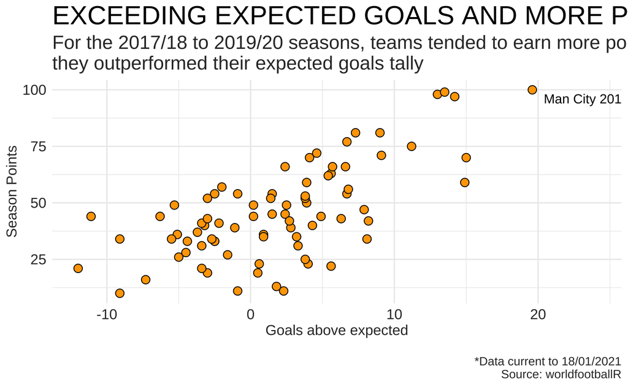

```r
end_season_summary %>%
  filter(Season_End_Year != 2021) %>%
  mutate(goals_above_expected = GF - xG) %>%
  ggplot(aes(x = goals_above_expected, y = Pts)) +
  geom_point(colour = "black", fill = "orange", shape = 21, size = 3) +
  labs(
    x = "Goals above expected", y = "Season Points",
    caption = "\n*Data current to 18/01/2021\nSource: worldfootballR",
     subtitle = "For the 2017/18 to 2019/20 seasons, teams tended to earn more points the more\nthey outperformed their expected goals tally",
    title = "EXCEEDING EXPECTED GOALS AND MORE POINTS"
  ) +
  annotate("text", x = 24, y = 96, label = "Man City 2017/18", family = "chivo")
```

## How are the Reds tracking?

```r
liv_cum_totals <- xg_data %>%
  select(Season_End_Year, Date, Team = Home, Goals = HomeGoals, xG = Home_xG) %>%
  mutate(
    HomeAway = "Home",
    goals_above_expected = Goals - xG
  ) %>%
  bind_rows(xg_data %>%
    select(Season_End_Year, Date, Team = Away, Goals = AwayGoals, xG = Away_xG) %>%
    mutate(
      HomeAway = "Away",
      goals_above_expected = Goals - xG
    )) %>%
  filter(Team == "Liverpool") %>%
  arrange(Season_End_Year, Date) %>%
  group_by(Season_End_Year) %>%
  mutate(game_num = row_number()) %>%
  filter(!is.na(Goals)) %>%
  group_by(Season_End_Year, game_num) %>%
  summarise(
    Goals = sum(Goals, na.rm = TRUE),
    xG = sum(xG, na.rm = TRUE)
  ) %>%
  ungroup() %>%
  mutate(goal_above_expected = Goals - xG) %>%
  group_by(Season_End_Year) %>%
  mutate(
    cum_total_goals = cumsum(Goals),
    cum_total_xg = cumsum(xG)
  ) %>%
  select(Season_End_Year, game_num, Goals = cum_total_goals, xG = cum_total_xg) %>%
  pivot_longer(cols = c(Goals:xG), names_to = "GoalType", values_to = "Goals")
lab_df <- liv_cum_totals %>%
  filter(Season_End_Year == 2018) %>%
  arrange(desc(game_num)) %>%
  distinct(Season_End_Year, GoalType, .keep_all = TRUE)
```

[figure not shown]

```r
liv_cum_totals %>%
  ggplot(aes(x = game_num, y = Goals, group = GoalType, colour = GoalType)) +
  geom_line(size = 1) +
  geom_text(data = lab_df, aes(x = game_num, y = Goals, label = GoalType, colour = GoalType), vjust = 0, family = "chivo") +
  scale_colour_manual(values = c("#C31014", alpha("#C31014", 0.4))) +
  labs(
    x = "Match Number", y = "Cumulative Goals",
    caption = "\n*Data current to 18/01/2021\nSource: worldfootballR",
    title = "LIVERPOOL SCORING AS EXPECTED THIS SEASON",
    subtitle = glue::glue("The gap between actual goals and expected goals remained consistently positive during\nLiverpool's championship run in 19/20, while this season sees them tracking xG closely")
  ) +
  facet_wrap(~Season_End_Year) +
  theme(legend.position = "none")
```

This current season, other than the 7-0 drubbing (xG of 2.2) against Crystal Palace at Selhurst Park, Liverpool’s goals tally has closely tracked the expected goals. The Reds marksmen just aren’t able to convert those guilt edge chances this season, which might explain the struggle at the top.